# Income Classification - Logistic Regression Example

Piotr Wieczorek

2023-05-20

## Goal of this project

### The goal of this project is to use logistic regression to predict the income group (either >50K or <=50K) based on the following variables:

#### age

#### work class

#### education

#### marital status

#### occupation

#### race

#### sex

#### hours per week (of work)

#### native country

## Libraries and reading the data

```r
library(tidyr)
library(tidyverse)
library(ROCit)
library(caret)
library(corrplot)
library(fastDummies)
library(performance)
library(psych)
library(gridExtra)
library(rcompanion)
library(coefplot)
library(kableExtra)
library(formatR)
library(pROC)
```

```r
rm(list = ls())
```

```r
df <- read_csv("C:/Users/piotr/Desktop/R_files/adult.csv")
```

## Exploring the data set

```r
colnames(df)
```

```
##  [1] "age"            "workclass"      "fnlwgt"         "education"
##  [5] "education.num"  "marital.status" "occupation"     "relationship"
##  [9] "race"           "sex"            "capital.gain"   "capital.loss"
## [13] "hours.per.week" "native.country" "income"
```

### Notice that several “?” signs occur in the data - they will be replaced with NaN values

```r
str(df)
```

```
## spc_tbl_ [32,561 × 15] (S3: spec_tbl_df/tbl_df/tbl/data.frame)
##  $ age           : num [1:32561] 90 82 66 54 41 34 38 74 68 41 ...
##  $ workclass     : chr [1:32561] "?" "Private" "?" "Private" ...
##  $ fnlwgt        : num [1:32561] 77053 132870 186061 140359 264663 ...
##  $ education     : chr [1:32561] "HS-grad" "HS-grad" "Some-college" "7th-8th" ...
##  $ education.num : num [1:32561] 9 9 10 4 10 9 6 16 9 10 ...
##  $ marital.status: chr [1:32561] "Widowed" "Widowed" "Widowed" "Divorced" ...
##  $ occupation    : chr [1:32561] "?" "Exec-managerial" "?" "Machine-op-inspct" ...
##  $ relationship  : chr [1:32561] "Not-in-family" "Not-in-family" "Unmarried" "Unmarried" ...
##  $ race          : chr [1:32561] "White" "White" "Black" "White" ...
##  $ sex           : chr [1:32561] "Female" "Female" "Female" "Female" ...
##  $ capital.gain  : num [1:32561] 0 0 0 0 0 0 0 0 0 0 ...
##  $ capital.loss  : num [1:32561] 4356 4356 4356 3900 3900 ...
##  $ hours.per.week: num [1:32561] 40 18 40 40 40 45 40 20 40 60 ...
##  $ native.country: chr [1:32561] "United-States" "United-States" "United-States" "United-States" ...
##  $ income        : chr [1:32561] "<=50K" "<=50K" "<=50K" "<=50K" ...
##  - attr(*, "spec")=
##   .. cols(
##   ..   age = col_double(),
##   ..   workclass = col_character(),
##   ..   fnlwgt = col_double(),
##   ..   education = col_character(),
##   ..   education.num = col_double(),
##   ..   marital.status = col_character(),
##   ..   occupation = col_character(),
##   ..   relationship = col_character(),
##   ..   race = col_character(),
##   ..   sex = col_character(),
##   ..   capital.gain = col_double(),
##   ..   capital.loss = col_double(),
##   ..   hours.per.week = col_double(),
##   ..   native.country = col_character(),
##   ..   income = col_character()
##   .. )
##  - attr(*, "problems")=<externalptr>
```

```r
length(df[df == "?"])
```

```
## [1] 4262
```

```r
df[df == "?"] <- NA
```

```r
sum(is.na(df))
```

```
## [1] 4262
```

```r
sapply(df, function(x) sum(is.na(df)))
```

```
##            age      workclass         fnlwgt      education  education.num
##           4262           4262           4262           4262           4262
## marital.status     occupation   relationship           race            sex
##           4262           4262           4262           4262           4262
##   capital.gain   capital.loss hours.per.week native.country         income
##           4262           4262           4262           4262           4262
```

### Before omitting NA values, let’s choose only these columns that will be used in the model

```r
df <- df %>%
    select(c("age", "workclass", "education", "marital.status",
        "occupation", "race", "sex", "hours.per.week", "native.country",
        "income"))
```

### NaN values couldn’t be replaced in this example e.g with mean, because of the specification of remained columns

```r
df <- na.omit(df)
```

### Let’s describe numeric variables

```r
df %>%
    select_if(is.numeric) %>%
    describe() %>%
    kable(align = "c") %>%
    kable_styling(position = "center") %>%
    scroll_box(width = "100%", height = "200px")
```

|  | vars | n | mean | sd | median | trimmed | mad | min | max | range | skew | kurtosis | se |
| --- | --- | --- | --- | --- | --- | --- | --- | --- | --- | --- | --- | --- | --- |
| age | 1 | 30162 | 38.43790 | 13.13466 | 37 | 37.64691 | 14.8260 | 17 | 90 | 73 | 0.5301750 | -0.1450384 | 0.0756291 |
| hours.per.week | 2 | 30162 | 40.93124 | 11.97998 | 40 | 40.96610 | 4.4478 | 1 | 99 | 98 | 0.3308364 | 3.1667551 | 0.0689805 |

### Change character variables to factors

```r
df <- df %>%
    mutate_if(is.character, as.factor)
```

```r
df %>%
    select_if(is.factor) %>%
    colnames()
```

```
## [1] "workclass"      "education"      "marital.status" "occupation"
## [5] "race"           "sex"            "native.country" "income"
```

### In this part, some categories of factor variables were aggregated in other categories in order to not only simplify the model, but also to get rid of near zero variance variables

```r
count(df, education, sort = TRUE)
```

```
## # A tibble: 16 × 2
##    education        n
##    <fct>        <int>
##  1 HS-grad       9840
##  2 Some-college  6678
##  3 Bachelors     5044
##  4 Masters       1627
##  5 Assoc-voc     1307
##  6 11th          1048
##  7 Assoc-acdm    1008
##  8 10th           820
##  9 7th-8th        557
## 10 Prof-school    542
## 11 9th            455
## 12 12th           377
## 13 Doctorate      375
## 14 5th-6th        288
## 15 1st-4th        151
## 16 Preschool       45
```

```r
df <- df %>%
    mutate(education = fct_collapse(education, Higher_education = c("Bachelors",
        "Masters"), High_school_graduate = "HS-grad", other_level = "Other_education"))
```

```r
count(df, workclass, sort = TRUE)
```

```
## # A tibble: 7 × 2
##   workclass            n
##   <fct>            <int>
## 1 Private          22286
## 2 Self-emp-not-inc  2499
## 3 Local-gov         2067
## 4 State-gov         1279
## 5 Self-emp-inc      1074
## 6 Federal-gov        943
## 7 Without-pay         14
```

```r
df <- df %>%
    mutate(workclass = fct_collapse(workclass, Gov_employed = c("Local-gov",
        "State-gov", "Federal-gov"), Self_employed = c("Self-emp-not-inc",
        "Self-emp-inc")))
```

### Note that without-pay category occurs only 14 times (it would be a near-zero-variance dummy variable). It was decided to delete these 14 rows from the dataset, as there is no real logical way to combine it with other categories

```r
df <- subset(df, !(workclass %in% "Without-pay"))
df$workclass <- droplevels(df$workclass)
```

```r
count(df, marital.status, sort = TRUE)
```

```
## # A tibble: 7 × 2
##   marital.status            n
##   <fct>                 <int>
## 1 Married-civ-spouse    14057
## 2 Never-married          9722
## 3 Divorced               4214
## 4 Separated               939
## 5 Widowed                 826
## 6 Married-spouse-absent   369
## 7 Married-AF-spouse        21
```

```r
df <- df %>%
    mutate(marital.status = fct_collapse(marital.status, Married = c("Married-civ-spouse",
        "Married-spouse-absent", "Married-AF-spouse"), other_level = "Not_married"))
```

```r
count(df, occupation, sort = TRUE)
```

```
## # A tibble: 14 × 2
##    occupation            n
##    <fct>             <int>
##  1 Prof-specialty     4038
##  2 Craft-repair       4029
##  3 Exec-managerial    3992
##  4 Adm-clerical       3718
##  5 Sales              3584
##  6 Other-service      3211
##  7 Machine-op-inspct  1965
##  8 Transport-moving   1571
##  9 Handlers-cleaners  1349
## 10 Farming-fishing     983
## 11 Tech-support        912
## 12 Protective-serv     644
## 13 Priv-house-serv     143
## 14 Armed-Forces          9
```

### Armed-Forces (n=9) and Priv-house serv (n=143) were deleted because there was no logical way to combine these categories with another categories and otherwise they would be near-zero-variance dummy variables

```r
df <- subset(df, !(occupation %in% c("Armed-Forces", "Priv-house-serv")))
df$occupation <- droplevels(df$occupation)
```

```r
count(df, race, sort = TRUE)
```

```
## # A tibble: 5 × 2
##   race                   n
##   <fct>              <int>
## 1 White              25805
## 2 Black               2788
## 3 Asian-Pac-Islander   890
## 4 Amer-Indian-Eskimo   285
## 5 Other                228
```

```r
df <- df %>%
    mutate(race = fct_collapse(race, Other_race = c("Other",
        "Amer-Indian-Eskimo", "Asian-Pac-Islander")))
```

```r
count(df, sex, sort = TRUE)
```

```
## # A tibble: 2 × 2
##   sex        n
##   <fct>  <int>
## 1 Male   20354
## 2 Female  9642
```

```r
count(df, native.country, sort = TRUE)
```

```
## # A tibble: 41 × 2
##    native.country     n
##    <fct>          <int>
##  1 United-States  27392
##  2 Mexico           593
##  3 Philippines      185
##  4 Germany          127
##  5 Puerto-Rico      109
##  6 Canada           107
##  7 India            100
##  8 El-Salvador       94
##  9 Cuba              90
## 10 England           83
## # … with 31 more rows
```

```r
df <- df %>%
    mutate(native.country = fct_collapse(native.country, USA = c("United-States"),
        Europe = c("Germany", "England", "Poland", "Italy", "Portugal",
            "Greece", "France", "Ireland", "Yugoslavia", "Hungary",
            "Scotland", "Holand-Netherlands"), other_level = "Other")) %>%
    rename(Native_region = "native.country")
```

```r
count(df, income, sort = TRUE)
```

```
## # A tibble: 2 × 2
##   income     n
##   <fct>  <int>
## 1 <=50K  22490
## 2 >50K    7506
```

## Additional Data exploration

### It’s clear that mean, median and mode of age is higher for >50k income

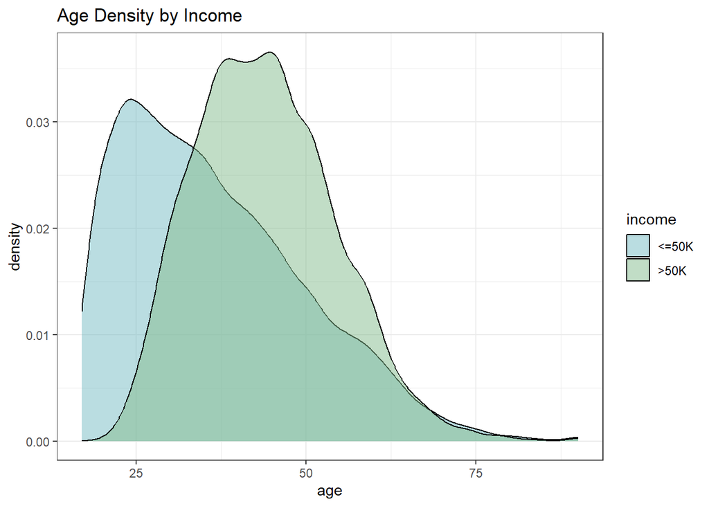

```r
df %>%
    ggplot(aes(x = age, fill = income)) + geom_density(alpha = 0.5) +
    scale_fill_manual(values = c("#76BBC3", "#84BC8E")) + theme_bw() +
    ggtitle("Age Density by Income")
```

### Based on the plots below, one could conclude that:

#### Occupation plays an important role especially considering executive categories

#### Sex is also an important factor as men tend to have a higher income than women

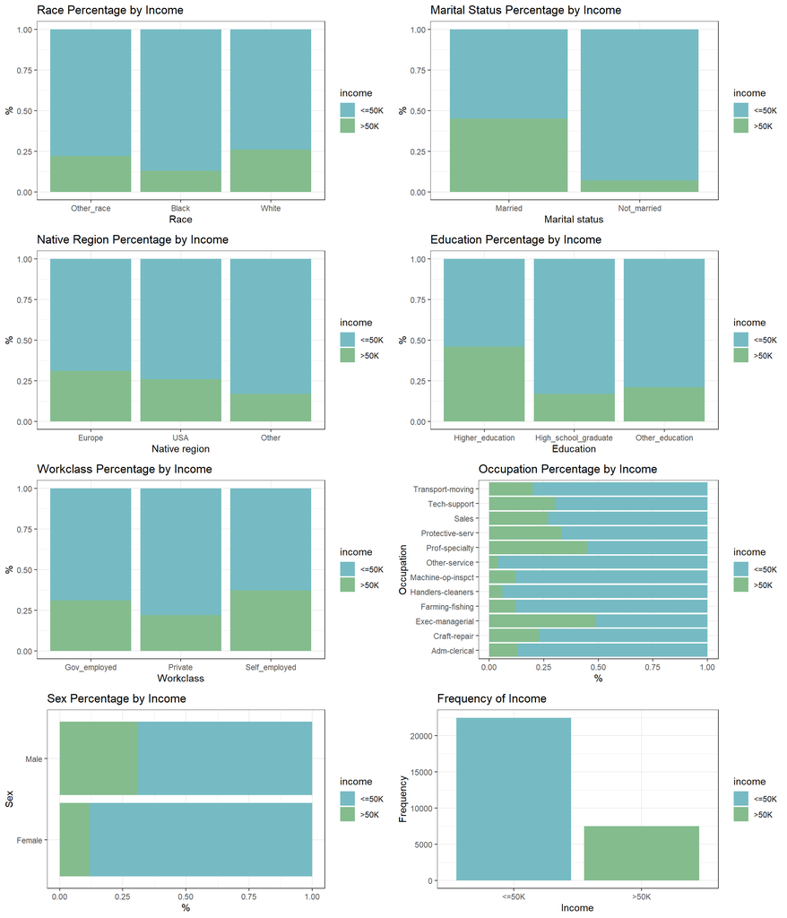

```r
grid.arrange(
  count(df,race,income) %>%
  group_by(race) %>%
  mutate(percent = n/sum(n)) %>%
  mutate(percent = round(percent,2)) %>%
  ggplot(aes(x=race,y=percent,fill=income)) +
  geom_bar(stat="identity") +
  scale_fill_manual(values=c("#76BBC3","#84BC8E")) +
  theme_bw()+
  xlab("Race")+
  ylab("%")+
  ggtitle("Race Percentage by Income")+
  theme_bw(),

  count(df,marital.status,income) %>%
  group_by(marital.status) %>%
  mutate(percent = n/sum(n)) %>%
  mutate(percent = round(percent,2)) %>%
  ggplot(aes(x=marital.status,y=percent,fill=income)) +
  geom_bar(stat="identity") +
  scale_fill_manual(values=c("#76BBC3","#84BC8E")) +
  theme_bw()+
  xlab("Marital status")+
  ylab("%")+
  ggtitle("Marital Status Percentage by Income")+
  theme_bw(),

  count(df,Native_region,income) %>%
  group_by(Native_region) %>%
  mutate(percent = n/sum(n)) %>%
  mutate(percent = round(percent,2)) %>%
  ggplot(aes(x=Native_region,y=percent,fill=income)) +
  geom_bar(stat="identity")+
  scale_fill_manual(values=c("#76BBC3","#84BC8E")) +
  xlab("Native region")+
  ylab("%")+
  ggtitle("Native Region Percentage by Income") +
  theme_bw(),

  count(df,education,income) %>%
  group_by(education) %>%
  mutate(percent = n/sum(n)) %>%
  mutate(percent = round(percent,2)) %>%
  ggplot(aes(x=education,y=percent,fill=income)) +
  geom_bar(stat="identity")+
  scale_fill_manual(values=c("#76BBC3","#84BC8E")) +
  xlab("Education")+
  ylab("%")+
  ggtitle("Education Percentage by Income") +
  theme_bw(),

  count(df,workclass,income) %>%
  group_by(workclass) %>%
  mutate(percent = n/sum(n)) %>%
  mutate(percent = round(percent,2)) %>%
  ggplot(aes(x=workclass,y=percent,fill=income)) +
  geom_bar(stat="identity")+
  scale_fill_manual(values=c("#76BBC3","#84BC8E")) +
  xlab("Workclass")+
  ylab("%")+
  ggtitle("Workclass Percentage by Income")+
  theme_bw(),

  count(df,occupation,income) %>%
  group_by(occupation) %>%
  mutate(percent = n/sum(n)) %>%
  mutate(percent = round(percent,2)) %>%
  ggplot(aes(y=occupation,x=percent,fill=income)) +
  geom_bar(stat="identity")+
  scale_fill_manual(values=c("#76BBC3","#84BC8E")) +
  ylab("Occupation")+
  xlab("%")+
  ggtitle("Occupation Percentage by Income")+
  theme_bw(),

  count(df,sex,income) %>%
  group_by(sex) %>%
  mutate(percent = n/sum(n)) %>%
  mutate(percent = round(percent,2)) %>%
  ggplot(aes(y=sex,x=percent,fill=income)) +
  geom_bar(stat="identity")+
  scale_fill_manual(values=c("#76BBC3","#84BC8E")) +
  ylab("Sex")+
  xlab("%")+
  ggtitle("Sex Percentage by Income") +
  theme_bw(),

  count(df,income) %>%
  ggplot(aes(x=income,y=n,fill=income)) +
  geom_bar(stat="identity")+
  scale_fill_manual(values=c("#76BBC3","#84BC8E")) +
  xlab("Income")+
  ylab("Frequency")+
  ggtitle("Frequency of Income") +
  theme_bw(),


  ncol = 2,nrow=4
)
```

### Let’s explore the variable’s dependency based on the Chi-squared test and the Cramer V score

```r
df_chi <- data.frame()
for (i in c("workclass", "education", "marital.status", "occupation",
    "race", "sex", "Native_region")) {
    chi_test = chisq.test(df[[i]], df$income)
    chi_stat = chi_test$statistic
    cramer = cramerV(df[[i]], df$income)
    variable_name = i
    output = c(chi_stat, cramer, variable_name)
    df_chi = rbind(df_chi, output)
}

colnames(df_chi) <- c("chisq_stat", "cramer's v", "var_name")

df_chi <- df_chi %>%
    select(3, 1, 2) %>%
    mutate(chisq_stat = as.numeric(chisq_stat), `cramer's v` = as.numeric(`cramer's v`)) %>%
    mutate(chisq_stat = round(chisq_stat, 2), `cramer's v` = round(`cramer's v`,
        2)) %>%
    arrange(desc(`cramer's v`))

df_chi %>%
    kable(align = "c") %>%
    kable_styling(position = "center")
```

| var_name | chisq_stat | cramer’s v |
| --- | --- | --- |
| marital.status | 5696.26 | 0.44 |
| occupation | 3625.62 | 0.35 |
| education | 2003.98 | 0.26 |
| sex | 1379.42 | 0.21 |
| workclass | 445.14 | 0.12 |
| race | 248.84 | 0.09 |
| Native_region | 81.65 | 0.05 |

## Modelling part - first model

### Data partition

```r
set.seed(355)
partition <- createDataPartition(y = df$income, p = 0.7, list = FALSE)
train_set <- df[partition, ]
test_set <- df[-partition, ]

print(nrow(train_set))
```

```
## [1] 20998
```

```r
print(nrow(test_set))
```

```
## [1] 8998
```

```r
print(nrow(train_set)/nrow(df))
```

```
## [1] 0.7000267
```

```r
print(nrow(test_set)/nrow(df))
```

```
## [1] 0.2999733
```

### Let’s try the first model with all variables. It’s clear that it’s not the best approach and as expected, some variables contribute very little to the model

```r
first_model <- glm(formula = income ~ ., data = train_set, family = "binomial")
summary(first_model)
```

```
##
## Call:
## glm(formula = income ~ ., family = "binomial", data = train_set)
##
## Deviance Residuals:
##     Min       1Q   Median       3Q      Max
## -2.5930  -0.6195  -0.2669   0.3774   3.1783
##
## Coefficients:
##                                Estimate Std. Error z value Pr(>|z|)
## (Intercept)                   -2.528777   0.231191 -10.938  < 2e-16 ***
## age                            0.029095   0.001703  17.086  < 2e-16 ***
## workclassPrivate               0.074898   0.059501   1.259  0.20811
## workclassSelf_employed        -0.024178   0.076644  -0.315  0.75242
## educationHigh_school_graduate -0.912693   0.058314 -15.651  < 2e-16 ***
## educationOther_education      -0.718474   0.050680 -14.177  < 2e-16 ***
## marital.statusNot_married     -2.201422   0.051908 -42.410  < 2e-16 ***
## occupationCraft-repair        -0.274223   0.087214  -3.144  0.00167 **
## occupationExec-managerial      0.859762   0.083704  10.272  < 2e-16 ***
## occupationFarming-fishing     -1.467736   0.150220  -9.771  < 2e-16 ***
## occupationHandlers-cleaners   -1.191643   0.161795  -7.365 1.77e-13 ***
## occupationMachine-op-inspct   -0.701662   0.113027  -6.208 5.37e-10 ***
## occupationOther-service       -1.129024   0.126923  -8.895  < 2e-16 ***
## occupationProf-specialty       0.939913   0.083517  11.254  < 2e-16 ***
## occupationProtective-serv      0.299916   0.138933   2.159  0.03087 *
## occupationSales                0.190889   0.089482   2.133  0.03290 *
## occupationTech-support         0.722622   0.122596   5.894 3.76e-09 ***
## occupationTransport-moving    -0.648510   0.110068  -5.892 3.82e-09 ***
## raceBlack                     -0.181077   0.131874  -1.373  0.16972
## raceWhite                     -0.087198   0.109057  -0.800  0.42396
## sexMale                        0.297903   0.056796   5.245 1.56e-07 ***
## hours.per.week                 0.032736   0.001835  17.836  < 2e-16 ***
## Native_regionUSA              -0.031943   0.148914  -0.215  0.83015
## Native_regionOther            -0.564330   0.175356  -3.218  0.00129 **
## ---
## Signif. codes:  0 '***' 0.001 '**' 0.01 '*' 0.05 '.' 0.1 ' ' 1
##
## (Dispersion parameter for binomial family taken to be 1)
##
##     Null deviance: 23628  on 20997  degrees of freedom
## Residual deviance: 16082  on 20974  degrees of freedom
## AIC: 16130
##
## Number of Fisher Scoring iterations: 6
```

```r
prediction <- predict(object = first_model, test_set, type = "response")
```

```r
head(prediction)
```

```
##          1          2          3          4          5          6
## 0.13559562 0.01269451 0.13941281 0.29209013 0.11442592 0.15981315
```

```r
prediction_group <- ifelse(prediction >= 0.5, ">50K", "<=50K")
```

```r
head(prediction_group)
```

```
##       1       2       3       4       5       6
## "<=50K" "<=50K" "<=50K" "<=50K" "<=50K" "<=50K"
```

### Confusion matrix for the first model - 81.93% accuracy score with all variables included

```r
confusionMatrix(data = as.factor(prediction_group), reference = test_set$income,
    positive = ">50K")
```

```
## Confusion Matrix and Statistics
##
##           Reference
## Prediction <=50K >50K
##      <=50K  6176 1055
##      >50K    571 1196
##
##                Accuracy : 0.8193
##                  95% CI : (0.8112, 0.8272)
##     No Information Rate : 0.7498
##     P-Value [Acc > NIR] : < 2.2e-16
##
##                   Kappa : 0.4812
##
##  Mcnemar's Test P-Value : < 2.2e-16
##
##             Sensitivity : 0.5313
##             Specificity : 0.9154
##          Pos Pred Value : 0.6769
##          Neg Pred Value : 0.8541
##              Prevalence : 0.2502
##          Detection Rate : 0.1329
##    Detection Prevalence : 0.1964
##       Balanced Accuracy : 0.7233
##
##        'Positive' Class : >50K
##
```

### AUC Score

```r
sim_roc1 <- roc(response = test_set$income, predictor = prediction,
    levels = c(">50K", "<=50K"))
```

```r
auc(sim_roc1)
```

```
## Area under the curve: 0.8681
```

## Second model

### In this model race and work class were excluded

```r
second_model <- glm(formula = income ~ . - race - workclass,
    data = train_set, family = "binomial")
summary(second_model)
```

```
##
## Call:
## glm(formula = income ~ . - race - workclass, family = "binomial",
##     data = train_set)
##
## Deviance Residuals:
##     Min       1Q   Median       3Q      Max
## -2.6101  -0.6202  -0.2682   0.3789   3.1476
##
## Coefficients:
##                                Estimate Std. Error z value Pr(>|z|)
## (Intercept)                   -2.533291   0.200813 -12.615  < 2e-16 ***
## age                            0.028508   0.001677  16.999  < 2e-16 ***
## educationHigh_school_graduate -0.912598   0.058141 -15.696  < 2e-16 ***
## educationOther_education      -0.719946   0.050470 -14.265  < 2e-16 ***
## marital.statusNot_married     -2.200981   0.051790 -42.498  < 2e-16 ***
## occupationCraft-repair        -0.268036   0.086454  -3.100  0.00193 **
## occupationExec-managerial      0.857653   0.082879  10.348  < 2e-16 ***
## occupationFarming-fishing     -1.501108   0.147178 -10.199  < 2e-16 ***
## occupationHandlers-cleaners   -1.182121   0.161301  -7.329 2.32e-13 ***
## occupationMachine-op-inspct   -0.683049   0.112073  -6.095 1.10e-09 ***
## occupationOther-service       -1.131046   0.126662  -8.930  < 2e-16 ***
## occupationProf-specialty       0.931531   0.083145  11.204  < 2e-16 ***
## occupationProtective-serv      0.265641   0.136164   1.951  0.05107 .
## occupationSales                0.195084   0.087801   2.222  0.02629 *
## occupationTech-support         0.733508   0.122298   5.998 2.00e-09 ***
## occupationTransport-moving    -0.639168   0.109687  -5.827 5.64e-09 ***
## sexMale                        0.299746   0.056580   5.298 1.17e-07 ***
## hours.per.week                 0.032510   0.001824  17.828  < 2e-16 ***
## Native_regionUSA              -0.037986   0.148923  -0.255  0.79867
## Native_regionOther            -0.532045   0.168898  -3.150  0.00163 **
## ---
## Signif. codes:  0 '***' 0.001 '**' 0.01 '*' 0.05 '.' 0.1 ' ' 1
##
## (Dispersion parameter for binomial family taken to be 1)
##
##     Null deviance: 23628  on 20997  degrees of freedom
## Residual deviance: 16087  on 20978  degrees of freedom
## AIC: 16127
##
## Number of Fisher Scoring iterations: 6
```

```r
prediction_second <- predict(object = second_model, test_set,
    type = "response")
```

```r
head(prediction_second)
```

```
##          1          2          3          4          5          6
## 0.12961179 0.01232538 0.14174061 0.28606663 0.11125124 0.15674239
```

```r
prediction_second_group <- ifelse(prediction_second >= 0.5, ">50K",
    "<=50K")
```

```r
head(prediction_second_group)
```

```
##       1       2       3       4       5       6
## "<=50K" "<=50K" "<=50K" "<=50K" "<=50K" "<=50K"
```

### Confustion matrix for the second model with 81.81% accuracy score, but with fewer variables which overall makes the model less complicated

```r
confusionMatrix(data = as.factor(prediction_second_group), reference = test_set$income,
    positive = ">50K")
```

```
## Confusion Matrix and Statistics
##
##           Reference
## Prediction <=50K >50K
##      <=50K  6168 1058
##      >50K    579 1193
##
##                Accuracy : 0.8181
##                  95% CI : (0.8099, 0.826)
##     No Information Rate : 0.7498
##     P-Value [Acc > NIR] : < 2.2e-16
##
##                   Kappa : 0.4781
##
##  Mcnemar's Test P-Value : < 2.2e-16
##
##             Sensitivity : 0.5300
##             Specificity : 0.9142
##          Pos Pred Value : 0.6733
##          Neg Pred Value : 0.8536
##              Prevalence : 0.2502
##          Detection Rate : 0.1326
##    Detection Prevalence : 0.1969
##       Balanced Accuracy : 0.7221
##
##        'Positive' Class : >50K
##
```

### AUC Score

```r
sim_roc2 <- roc(response = test_set$income, predictor = prediction_second,
    levels = c(">50K", "<=50K"))
```

```r
auc(sim_roc2)
```

```
## Area under the curve: 0.8681
```

## Third model

### This model excludes race, workclass and native region. Note that all of these 3 variables were the least related to the dependent variable (income) based on the Cramer’s V result. This time all of the variables are statistically significant.

```r
third_model <- glm(formula = income ~ . - race - workclass -
    Native_region, data = train_set, family = "binomial")
summary(third_model)
```

```
##
## Call:
## glm(formula = income ~ . - race - workclass - Native_region,
##     family = "binomial", data = train_set)
##
## Deviance Residuals:
##     Min       1Q   Median       3Q      Max
## -2.6048  -0.6238  -0.2680   0.3824   3.0815
##
## Coefficients:
##                                Estimate Std. Error z value Pr(>|z|)
## (Intercept)                   -2.643570   0.134588 -19.642  < 2e-16 ***
## age                            0.028881   0.001675  17.245  < 2e-16 ***
## educationHigh_school_graduate -0.889624   0.057892 -15.367  < 2e-16 ***
## educationOther_education      -0.718517   0.050381 -14.262  < 2e-16 ***
## marital.statusNot_married     -2.183470   0.051570 -42.340  < 2e-16 ***
## occupationCraft-repair        -0.266499   0.086357  -3.086  0.00203 **
## occupationExec-managerial      0.869757   0.082781  10.507  < 2e-16 ***
## occupationFarming-fishing     -1.502315   0.146837 -10.231  < 2e-16 ***
## occupationHandlers-cleaners   -1.198734   0.160975  -7.447 9.57e-14 ***
## occupationMachine-op-inspct   -0.710808   0.111731  -6.362 1.99e-10 ***
## occupationOther-service       -1.180474   0.126441  -9.336  < 2e-16 ***
## occupationProf-specialty       0.935467   0.083092  11.258  < 2e-16 ***
## occupationProtective-serv      0.277272   0.135990   2.039  0.04146 *
## occupationSales                0.203957   0.087692   2.326  0.02003 *
## occupationTech-support         0.741492   0.122087   6.073 1.25e-09 ***
## occupationTransport-moving    -0.629191   0.109617  -5.740 9.47e-09 ***
## sexMale                        0.304453   0.056448   5.394 6.91e-08 ***
## hours.per.week                 0.032720   0.001822  17.956  < 2e-16 ***
## ---
## Signif. codes:  0 '***' 0.001 '**' 0.01 '*' 0.05 '.' 0.1 ' ' 1
##
## (Dispersion parameter for binomial family taken to be 1)
##
##     Null deviance: 23628  on 20997  degrees of freedom
## Residual deviance: 16123  on 20980  degrees of freedom
## AIC: 16159
##
## Number of Fisher Scoring iterations: 6
```

### Coefficient plot for the third model

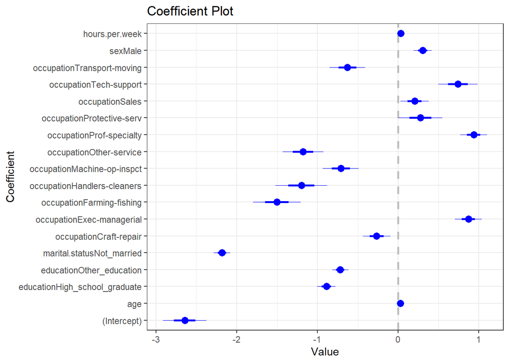

```r
coefplot(third_model) + theme_bw()
```

### From the coefficient plot and from the model’s result it is clear that:

#### Male workers are more likely to have a higher income than female workers

#### Tranpost-moving workers are less likely to have a higher income compared to Adm-clerical workers

#### Tech support workers are more likely to have a higher income compared to Adm-clerical workers

#### Sales workers are more likely to have a higher income compared to Adm-clerical workers

#### Protective-Serv workers are more likely to have a higher income compared to Adm-clerical workers

#### Protective-Serv workers are more likely to have a higher income compared to Adm-clerical workers

#### Prof-specialty workers are more likely to have a higher income compared to Adm-clerical workers

#### Other service workers are less likely to have a higher income compared to Adm-clerical workers

#### Machine-op-inspct workers are less likely to have a higher income compared to Adm-clerical workers

#### Handlers-cleaners workers are less likely to have a higher income compared to Adm-clerical workers

#### Farming-fishing workers are less likely to have a higher income compared to Adm-clerical workers

#### Exec-managerial workers are more likely to have a higher income compared to Adm-clerical workers

#### Craft-repair workers are less likely to have a higher income compared to Adm-clerical workers

#### Not married workers are less likely to have a higher income compared to married workers

#### Workers with “Other education” label are less likely to have a higher income compared to workers with higher education

#### Workers with “high school” education are less likely to have a higher income compared to workers with higher education

#### More hours per week results in better chance for getting a higher income

#### Increase in age results in better chance for getting a higher income

### To inspect the exact result of these measures, it would be helpful to calculate the exp() of each coefficient.

```r
exp(third_model$coefficients)
```

```
##                   (Intercept)                           age
##                    0.07110699                    1.02930192
## educationHigh_school_graduate      educationOther_education
##                    0.41081035                    0.48747464
##     marital.statusNot_married        occupationCraft-repair
##                    0.11264993                    0.76605674
##     occupationExec-managerial     occupationFarming-fishing
##                    2.38633045                    0.22261428
##   occupationHandlers-cleaners   occupationMachine-op-inspct
##                    0.30157571                    0.49124717
##       occupationOther-service      occupationProf-specialty
##                    0.30713317                    2.54840358
##     occupationProtective-serv               occupationSales
##                    1.31952479                    1.22624586
##        occupationTech-support    occupationTransport-moving
##                    2.09906501                    0.53302284
##                       sexMale                hours.per.week
##                    1.35588345                    1.03326141
```

### Interpretation:

#### Being a male results in having **35.59% higher odds (compared to females)** for getting the above 50k income label

```r
prediction_third <- predict(object = third_model, test_set, type = "response")
```

```r
head(prediction_third)
```

```
##          1          2          3          4          5          6
## 0.13127694 0.01162643 0.13961342 0.28312123 0.11066945 0.15437772
```

```r
prediction_third_group <- ifelse(prediction_third >= 0.5, ">50K",
    "<=50K")
```

```r
head(prediction_third_group)
```

```
##       1       2       3       4       5       6
## "<=50K" "<=50K" "<=50K" "<=50K" "<=50K" "<=50K"
```

### Confusion matrix for the third model

### This time we get 81.92% accuracy score which makes it almost identical with the first model in terms of accuracy, but this time we have 3 less variables so the model is easier to interprete.

```r
confusionMatrix(as.factor(prediction_third_group), test_set$income,
    positive = ">50K")
```

```
## Confusion Matrix and Statistics
##
##           Reference
## Prediction <=50K >50K
##      <=50K  6164 1044
##      >50K    583 1207
##
##                Accuracy : 0.8192
##                  95% CI : (0.8111, 0.8271)
##     No Information Rate : 0.7498
##     P-Value [Acc > NIR] : < 2.2e-16
##
##                   Kappa : 0.4827
##
##  Mcnemar's Test P-Value : < 2.2e-16
##
##             Sensitivity : 0.5362
##             Specificity : 0.9136
##          Pos Pred Value : 0.6743
##          Neg Pred Value : 0.8552
##              Prevalence : 0.2502
##          Detection Rate : 0.1341
##    Detection Prevalence : 0.1989
##       Balanced Accuracy : 0.7249
##
##        'Positive' Class : >50K
##
```

### ROC plot

```r
sim_roc3 <- roc(response = test_set$income, predictor = prediction_third,
    levels = c(">50K", "<=50K"))
```

```r
auc(sim_roc3)
```

```
## Area under the curve: 0.8671
```

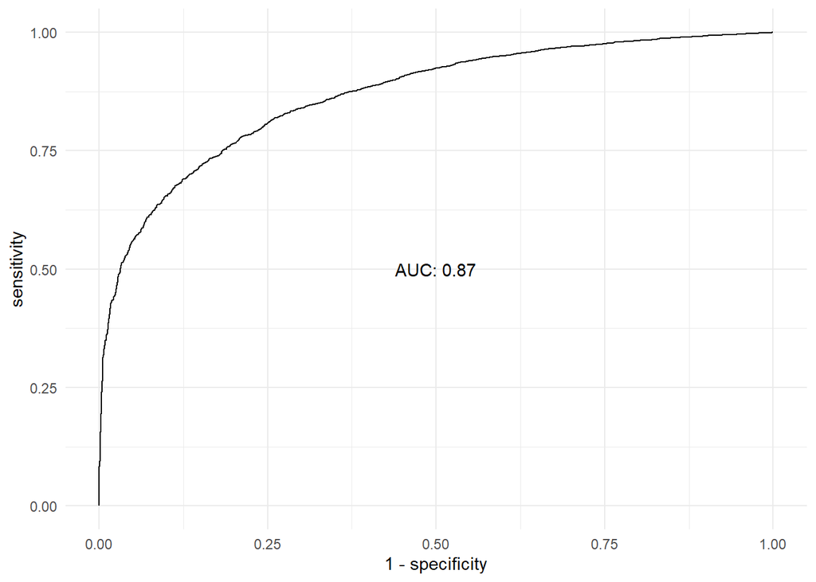

```r
ggroc(sim_roc3, legacy.axes = TRUE) + annotate("text", x = 0.5,
    y = 0.5, label = paste0("AUC: ", round(auc(sim_roc3), digits = 2))) +
    theme_minimal()
```

## Models comparison

```r
data.frame(sensitivity = c(sensitivity(as.factor(prediction_group),
    test_set$income), sensitivity(as.factor(prediction_second_group),
    test_set$income), sensitivity(as.factor(prediction_third_group),
    test_set$income)), model = c("first_model", "second_model",
    "third_model"), specificity = c(specificity(as.factor(prediction_group),
    test_set$income), specificity(as.factor(prediction_second_group),
    test_set$income), specificity(as.factor(prediction_third_group),
    test_set$income)), number_vars = c(23, 19, 17), AUC = c(auc(sim_roc1),
    auc(sim_roc2), auc(sim_roc3))) %>%
    select(2, 1, 3, 5, 4) %>%
    kable(align = "c") %>%
    kable_styling(position = "center")
```

| model | sensitivity | specificity | AUC | number_vars |
| --- | --- | --- | --- | --- |
| first_model | 0.9153698 | 0.5313194 | 0.8681426 | 23 |
| second_model | 0.9141841 | 0.5299867 | 0.8681195 | 19 |
| third_model | 0.9135912 | 0.5362061 | 0.8671178 | 17 |

## Conclusion

### It would be suggested to choose the third model as it’s simpler (has fewer variables) and its sensitivity, specificity and AUC score is almost identical in comparison with the first and the second model